# TMP Porewater ICP

## Counts

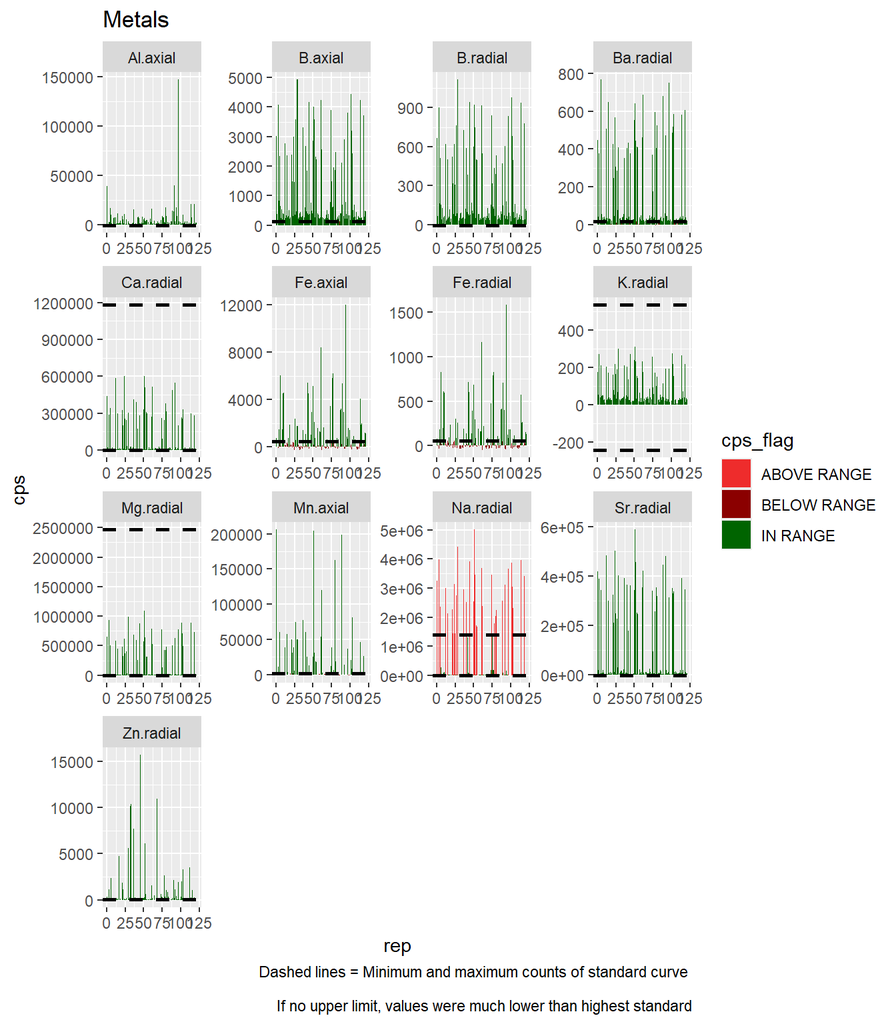

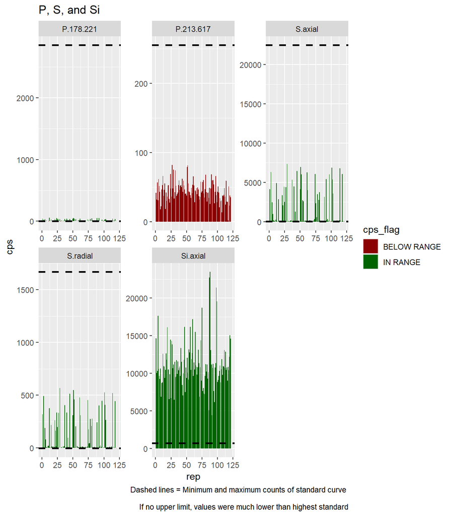

Red elements had <80% of samples within range of standard curve

| Element | Pass_percent | range_flag |
| --- | --- | --- |
| Al.axial | 100.0 | PASS |
| B.axial | 99.2 | PASS |
| B.radial | 100.0 | PASS |
| Ba.radial | 90.1 | PASS |
| Ca.radial | 100.0 | PASS |
| Fe.axial | 40.5 | FAIL |
| Fe.radial | 40.5 | FAIL |
| K.radial | 100.0 | PASS |
| Mg.radial | 100.0 | PASS |
| Mn.axial | 32.2 | FAIL |
| Na.radial | 72.7 | FAIL |
| P.178.221 | 60.3 | FAIL |
| P.213.617 | 0.0 | FAIL |
| S.axial | 88.4 | PASS |
| S.radial | 96.7 | PASS |
| Si.axial | 100.0 | PASS |
| Sr.radial | 100.0 | PASS |
| Zn.radial | 81.0 | PASS |

**Samples with low Fe Concentrations**

| total_number | percent_FW | percent_SW | percent_C |
| --- | --- | --- | --- |
| 72 | 61.1 | 33.3 | 5.6 |

## Asses Metal Check Standards

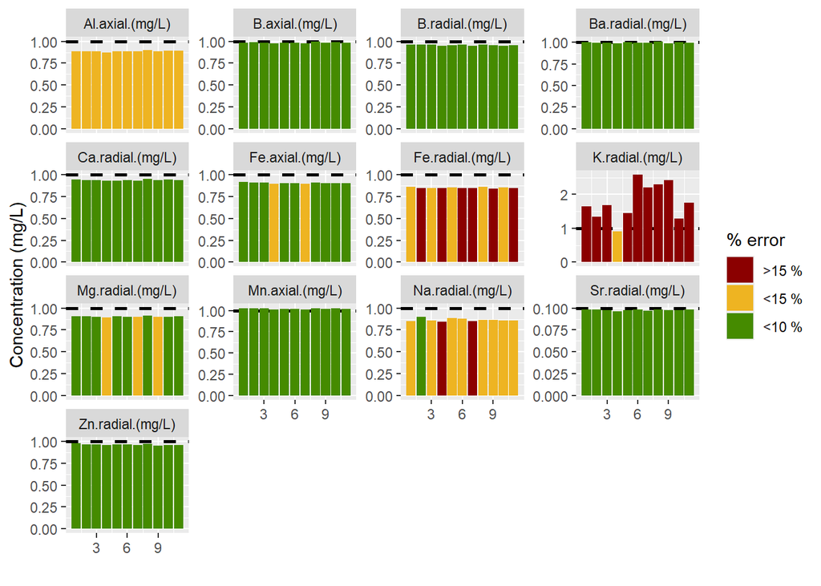

**LIST OF ELEMENTS WITH <80% OF CHECK STANDARDS WITHIN 15% OF EXPECTED CONCENTRATION - REASSESS**

| Element |
| --- |
| Fe.radial |
| K.radial |

## Assess P, S, and Si Check Standards

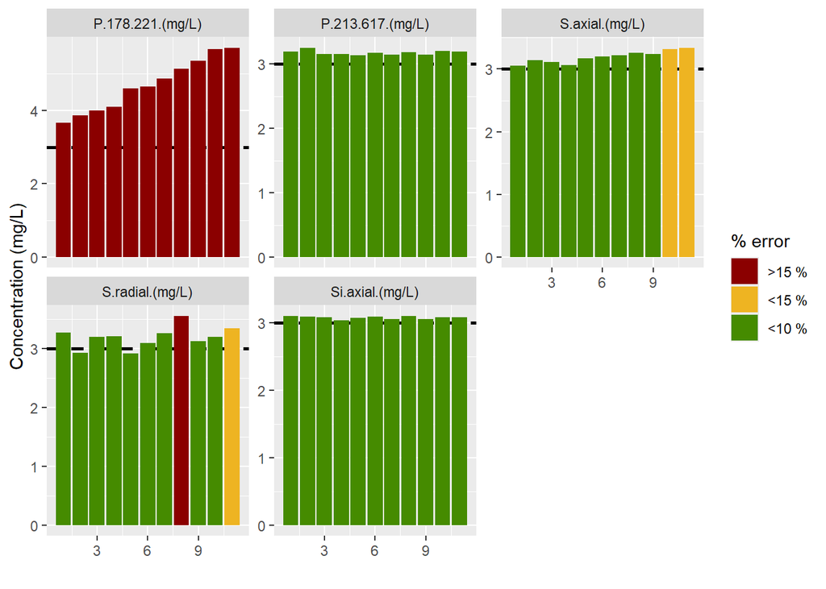

**LIST OF ELEMENTS WITH <80% OF CHECK STANDARDS WITHIN 15% OF EXPECTED CONCENTRATION - REASSESS**

| Element |
| --- |
| P.178.221 |

## Check Internal Standards

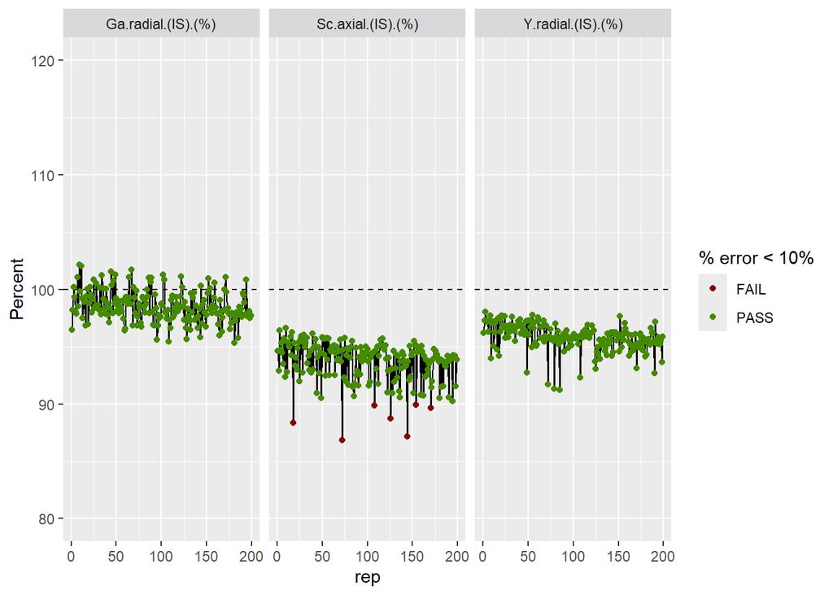

98.8274706867672 % of Internal Standards measurements are within 10% of 100

**Samples with low internal standard**[[1]] [1] “TMP_SW_F6_20230614_spk” “TMP_SW_B4_20240613_T4_spk” [3] “TMP_FW_C6_20240613_T5_spk” “TMP_SW_E3_20240613_T4_spk” [5] “TMP_SW_D5_20230617_spk” “TMP_SW_F6_20240613_T4”  
[7] “TMP_SW_B4_20240613_T5”

## Additional Checks

### NIST 1643f and Multi-elemental standard (QCS) are used as additional checks with a 10x dilution

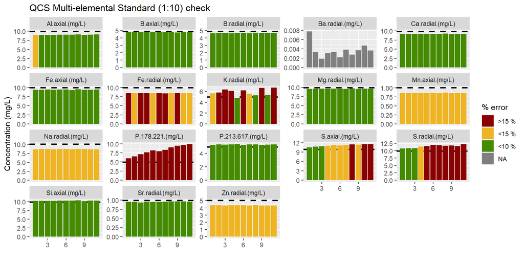

**LIST OF ELEMENTS WITH <80% OF CHECK STANDARDS WITHIN 15% OF EXPECTED CONCENTRATION - REASSESS**

| Element | Avg % Error |
| --- | --- |
| Fe.radial | 14.95 |
| K.radial | 18.34 |
| P.178.221 | 64.77 |
| S.axial | 12.45 |
| S.radial | 15.68 |

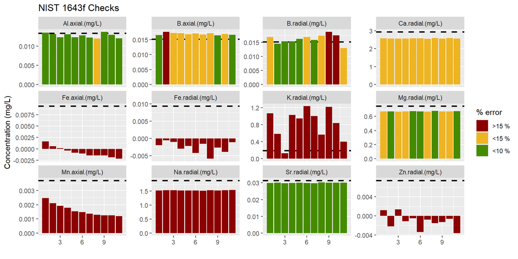

**LIST OF ELEMENTS WITH <80% OF NIST CHECKS WITHIN 15% OF EXPECTED CONCENTRATION - REASSESS**

| Element | Avg % Error |
| --- | --- |
| Fe.axial | 107.80 |
| Fe.radial | 127.05 |
| K.radial | 331.36 |
| Mn.axial | 56.79 |
| Na.radial | 18.89 |
| Zn.radial | 115.22 |

### Duplicate samples

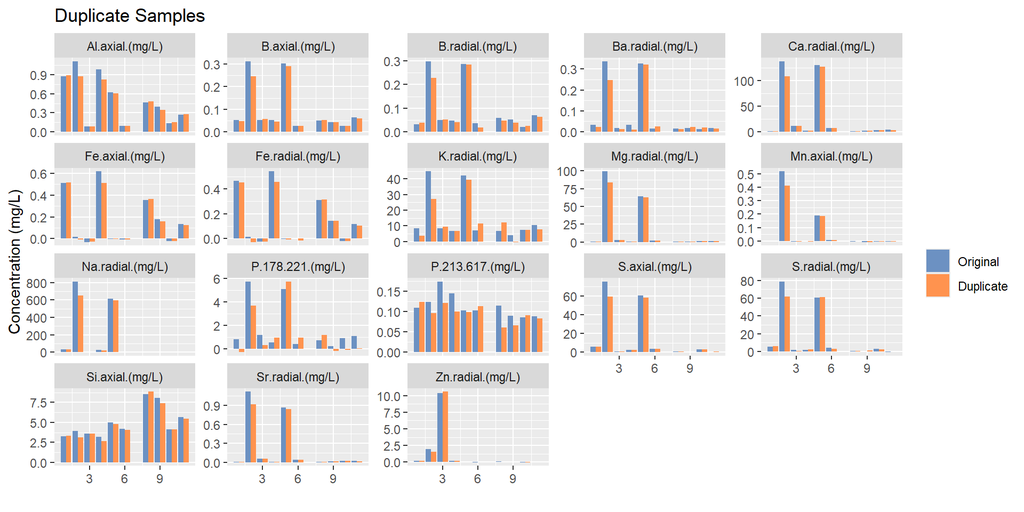

**LIST OF ELEMENTS WITH <80% OF DUPLICATE SAMPLES WITHIN 15% OF SAMPLE CONCENTRATION - REASSESS**

| Element | Avg % Difference |
| --- | --- |
| B.radial | 20.89 |
| Ba.radial | 35.59 |
| Fe.radial | 97.34 |
| K.radial | 53.26 |
| Mn.axial | 51.76 |
| Na.radial | 8.04 |
| P.178.221 | 313.77 |
| P.213.617 | 22.59 |
| S.axial | 21.76 |
| S.radial | 75.23 |
| Zn.radial | 24.56 |

### Sample Spikes

*Samples spiked with 0.2 mL of LFB (M10)*

NOTE: LFB was made incorrectly, theoretical concentration used instead

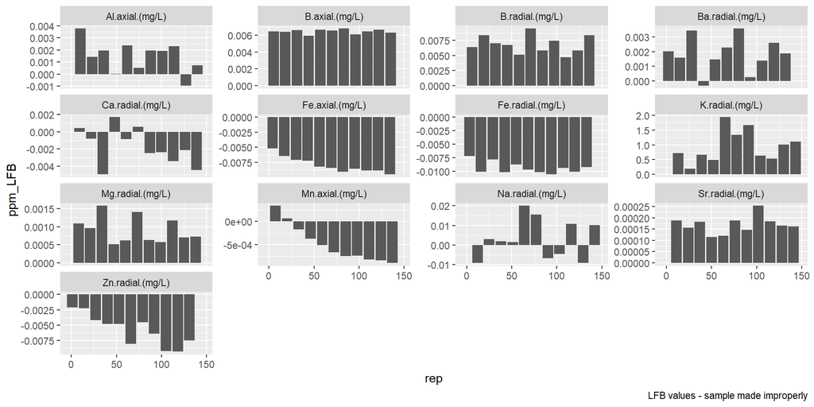

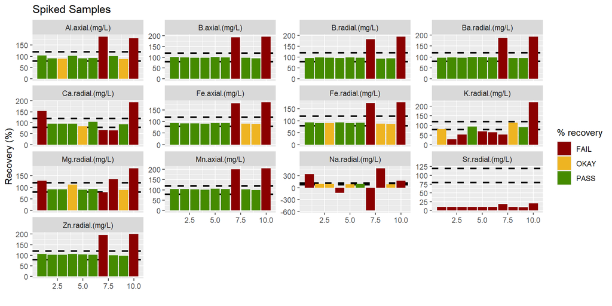

**LIST OF ELEMENTS WITH <80% OF SPIKED SAMPLES WITH 100 (+/- 20%) PERCENT RECOVERY - REASSESS**

| Element | Avg % Recovery |
| --- | --- |
| Ca.radial | 104.60 |
| K.radial | 86.72 |
| Mg.radial | 109.12 |
| Na.radial | 213.76 |
| Sr.radial | 11.72 |

# **Summary of QA/QC Results**

*Red elements did not pass QA/QC Checks*

Red elements did not pass QA/QC checks

| Element | Number of Checks | Fail (%) | Passed_checks | Failed_checks | QAQC |
| --- | --- | --- | --- | --- | --- |
| Al.axial | 6 | 0 | range, chk , NIST , QCS , dup , spk |  | PASS |
| B.axial | 6 | 0 | range, chk , NIST , QCS , dup , spk |  | PASS |
| B.radial | 6 | 17 | range, chk , NIST , QCS , spk | dup | PASS |
| Ba.radial | 4 | 25 | range, chk , spk | dup | FAIL |
| Ca.radial | 6 | 17 | range, chk , NIST , QCS , dup | spk | PASS |
| Fe.axial | 6 | 33 | chk, QCS, dup, spk | range, NIST | PASS |
| Fe.radial | 6 | 83 | spk | range, chk , NIST , QCS , dup | FAIL |
| K.radial | 6 | 83 | range | chk , NIST, QCS , dup , spk | FAIL |
| Mg.radial | 6 | 17 | range, chk , NIST , QCS , dup | spk | PASS |
| Mn.axial | 6 | 50 | chk, QCS, spk | range, NIST , dup | PASS |
| Na.radial | 6 | 67 | chk, QCS | range, NIST , dup , spk | PASS |
| P.178.221 | 4 | 100 |  | range, chk , QCS , dup | FAIL |
| P.213.617 | 4 | 50 | chk, QCS | range, dup | PASS |
| S.axial | 4 | 50 | range, chk | QCS, dup | FAIL |
| S.radial | 4 | 50 | range, chk | QCS, dup | FAIL |
| Si.axial | 4 | 0 | range, chk , QCS , dup |  | PASS |
| Sr.radial | 6 | 17 | range, chk , NIST , QCS , dup | spk | PASS |
| Zn.radial | 6 | 33 | range, chk , QCS , spk | NIST, dup | PASS |

# Sample Processing Steps

1. Sample concentrations were compared to blank concentrations. If sample concentration < blank concentration, then the sample concentration was set to zero.
2. Dilution factor was applied to each sample. In most cases, DF=5
3. Flags added to elments that had a poor standard curve.
4. Elements that did not pass QAQC were removed from the dataset
5. Removed samples that had low internal standards (<90%)
6. Column added to data listing elements that did not pass QAQC
7. Data exported to .csv

# Preliminary Plot of Data

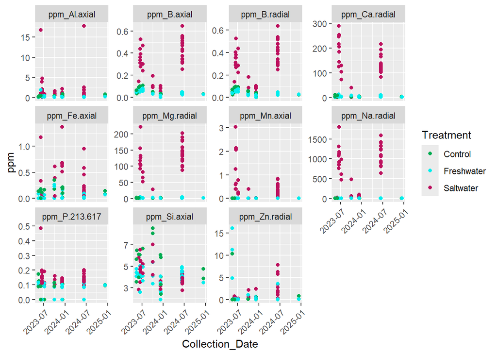

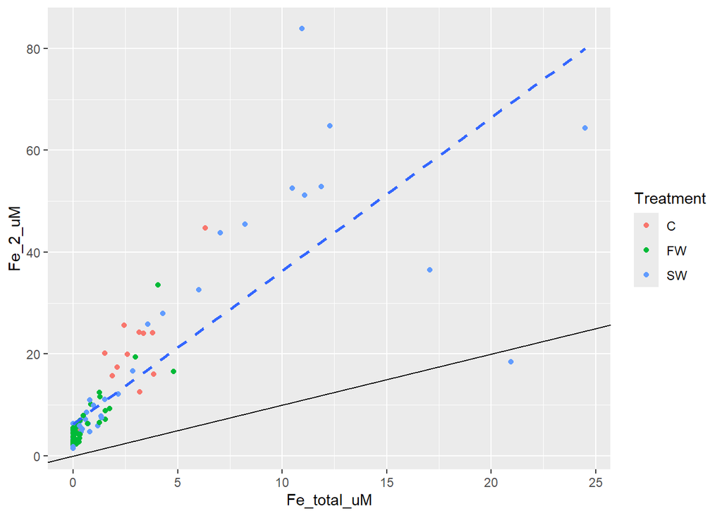

```r
Fe2.dat<-read.csv("C:/Users/ashmo/OneDrive - Arizona State University/Data/TEMPEST/Porewater/04_SummarizedData/TMP_Fe2_all.csv")



icp.fe<-dat.clean%>%
  select(Sample.Id,Treatment,DF,ppm_Fe.axial)%>%
  mutate(Fe_total_uM = (ppm_Fe.axial*1000)/55.845)%>%
  rename(Sample_ID = Sample.Id)



all.fe<-left_join(icp.fe,Fe2.dat, by ="Sample_ID")%>%
  mutate(DateTime = paste(Collection_Date,Collection_Time))%>%
  mutate(DateTime = as.POSIXct(DateTime,c("%Y%m%d %H%M"),tz="EST"))


p<-ggplot(all.fe,aes(x=Fe_total_uM,y=Fe_2_uM))+
  geom_point(aes(color = Treatment))+
  geom_smooth(method = "lm", linetype = "dashed",se=FALSE)+
  geom_abline(slope=1,intercept = 0)


print(p)
```

[figure not shown]

```r
p<-all.fe%>%
   pivot_longer(cols = c(Fe_2_uM,Fe_total_uM),
    names_to = "Fe_Type",
    values_to = "Fe_uM",
    values_drop_na = TRUE)%>%
  ggplot(aes(x= Sample_ID, y = Fe_uM))+
  geom_bar(stat = "identity",aes(fill = Fe_Type),position = position_dodge(1))+
  facet_wrap(~Treatment,scales="free",ncol=1)+
  theme(axis.text.x = element_text(angle = 45, hjust =1))


print(p)
```